# Modelling Competition- Team Beta

Adson Costanzi, Javier Fong, LA, Javich

January 16<sup>th</sup>, 2021

```r
knitr::opts_chunk$set(echo = TRUE)
require(dplyr)
require(ggplot2)
require(kableExtra)
require(reactable)
require(reactablefmtr)
require(CSGo)
require(readxl)
require(caret)
require(corrplot)
```

# Introduction

The goal of this project is to demonstrate some concepts that we learned in the “Regression Models” course applied to real data. For that purpose we are going to use a data set from **House Prices in King County** provided by the professor. We are going to explore this data set ether descriptively, and also testing some Regression Models to best predict the predict the house prices in King County.

# About the data

This data set includes 21613 rows one for each combination of id and date (there are 175 ids repited twice and 1 id repited three times) and 21 columns. The data is from 2014-05-02 to 2015-05-14.

- **id**: Identification number of the property (this variable is irrelevant for the analysis)
- **date**: Date house was sold
- **price**: Price (the prediction target)
- **bedrooms**: Number of Bedrooms/House
- **bathrooms**: Number of Bathrooms/Bedrooms
- **sqft living**: square footage of the home
- **sqft lot**: square footage of the lot
- **floors**: Total floors (levels) in house
- **waterfront**: House which has a view to a waterfront
- **view**: Has been viewed
- **condition**: How good the condition is (larger values mean better condition)
- **grade**: overall grade given to the housing unit, based on King County grading system (larger grades are better)
- **sqft above**: square footage of house apart from basement
- **sqft basement**: square footage of the basement
- **yr built**: Built Year
- **yr renovated**: Year when house was renovated
- **zipcode**: zip code
- **lat**: Latitude coordinate
- **long**: Longitude coordinate
- **sqft living15**: Living room area in 2015 (implies? some renovations) This might or might not have affected the lotsize area
- **sqft lot15**: lotSize area in 2015 (implies? some renovations)

Below it is possible to see a sample of the data:

| id | date | price | bedrooms | bathrooms | sqft_living | sqft_lot | floors | waterfront | view | condition | grade | sqft_above | sqft_basement | yr_built | yr_renovated | zipcode | lat | long | sqft_living15 | sqft_lot15 |
| --- | --- | --- | --- | --- | --- | --- | --- | --- | --- | --- | --- | --- | --- | --- | --- | --- | --- | --- | --- | --- |
| 7625702615 | 2015-01-14T00:00:00 | 400000 | 2 | 1 | 610 | 4560 | 1 | FALSE | 0 | 3 | 5 | 610 | 0 | 1918 | 0 | 98136 | 475498 | -122383 | 930 | 1392 |
| 7853280620 | 2014-12-12T00:00:00 | 689000 | 4 | 3.5 | 4490 | 5805 | 2 | FALSE | 0 | 3 | 9 | 3390 | 1100 | 2006 | 0 | 98065 | 475389 | -121.86 | 4410 | 6299 |
| 6169901095 | 2014-08-15T00:00:00 | 900000 | 4 | 2 | 1980 | 7200 | 2 | FALSE | 3 | 3 | 8 | 1700 | 280 | 1910 | 0 | 98119 | 476318 | -122369 | 2490 | 4200 |
| 1775930010 | 2014-12-22T00:00:00 | 335000 | 3 | 2.75 | 1990 | 19991 | 1 | FALSE | 0 | 3 | 7 | 1340 | 650 | 1977 | 0 | 98072 | 477434 | -122106 | 1750 | 9775 |
| 3670500465 | 2014-05-26T00:00:00 | 370000 | 3 | 2.5 | 1780 | 4050 | 2 | FALSE | 0 | 3 | 7 | 1780 | 0 | 2001 | 0 | 98155 | 477346 | -122308 | 1571 | 4976 |

## Data cleaning

The second step we are going to perform will be to divide our data set in train and test. The train data set will be used to the descriptive and also to train the regression models, it will contains 80% of our data. The test data set will be the remaining 20% data that we will use only to evaluate how our model will perform with unknown data.

```r
require(caret)

# create Data Partition
set.seed(1992)
intrain <- createDataPartition(data$price, p = 0.8, list = FALSE)

db_train <- data[intrain,]
db_test <- data[-intrain,]
```

## Basic Descriptive

In order to understand and summarize our target variable data set we are going to perform some descriptive analysis in our train data set as follows.

### Continuous Variables

Below it is presented some descriptive analysis for the continuous variables.

#### **price**

Below it is represented the histogram and the density of the variable. It is possible to see that the distribution of price is asymmetric with a tail in the right.

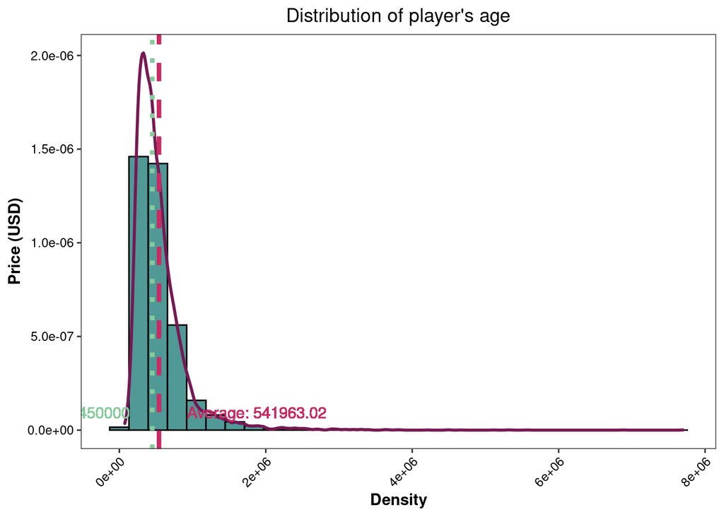

```r
require(ggplot2)
require(CSGo)

avg <- round(mean(db_train$price),2)
median <- round(median(db_train$price),2)

# histogram and density
db_train %>%
  ggplot(aes(x = price)) +
  geom_histogram(
    aes(y = ..density..),
    bins = 30,
    fill = "#509997",
    color = "black") +
  geom_density(color = "#761954", size = 1) +
  geom_vline(
    xintercept = avg,
    linetype = "dashed",
    color = "#c62d64",
    size = 1.5) +
  geom_text(aes(avg, 0, label = paste("Average:", avg), hjust = -0.2, vjust = -1), color = "#c62d64") +
  geom_vline(
    xintercept = median,
    linetype = "dotted",
    color = "#87ca9d",
    size = 1.5) +
  geom_text(aes(median, 0, label = paste("Median:", median), hjust = 1.2, vjust = -1), color = "#87ca9d") +
  ggtitle("Distribution of player's age") +
  CSGo::theme_csgo() +
  ylab("Price (USD)") +
  xlab("Density")
```

Lets also create a normal qqplot to see if the prices fits a normal distribution.

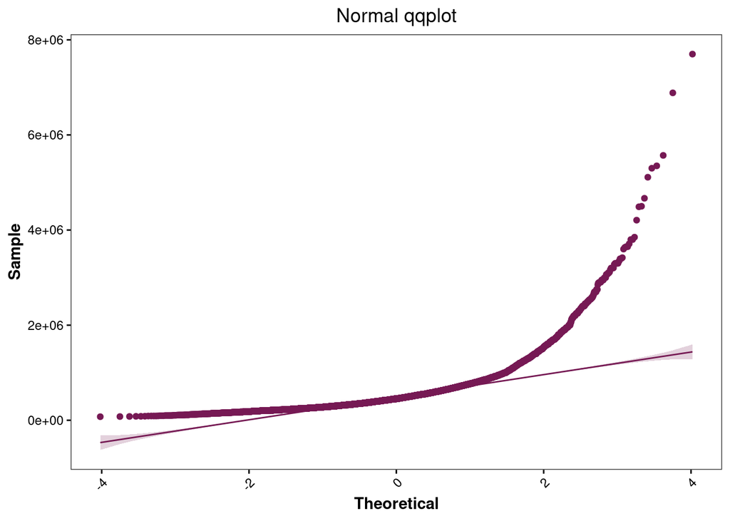

#### **sqft_living**

Below it is represented the histogram and the density of the variable. It is possible to see that the distribution of sqft_living is kind of symmetric but with some atypical values to the right.

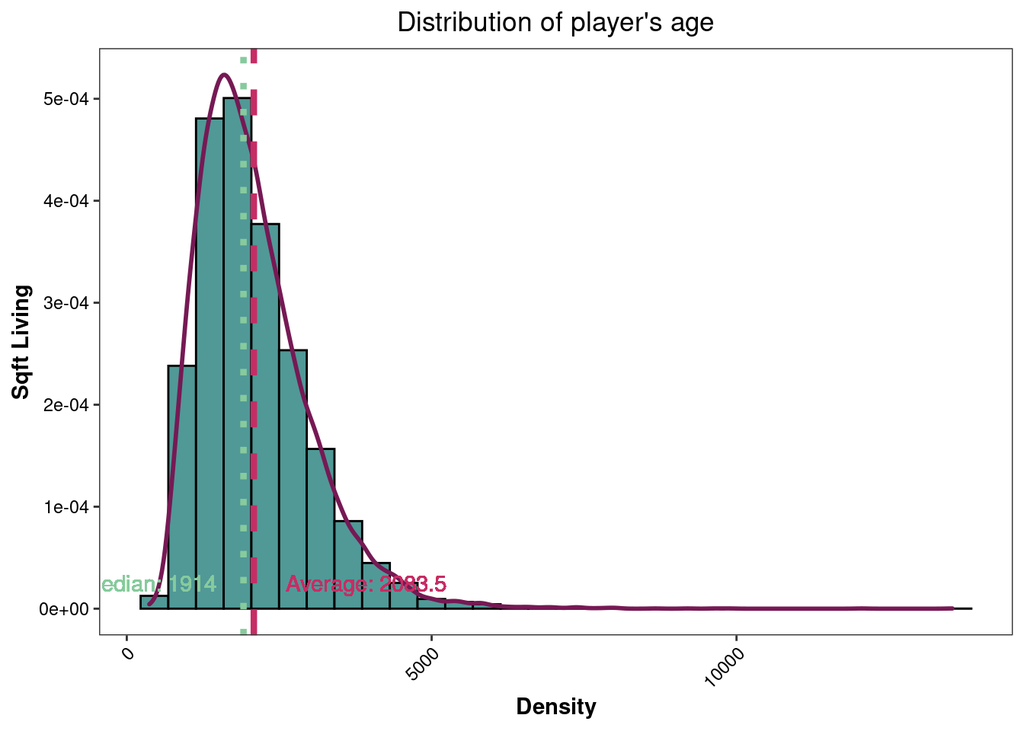

```r
avg <- round(mean(db_train$sqft_living),2)
median <- round(median(db_train$sqft_living),2)

# histogram and density
db_train %>%
  ggplot(aes(x = sqft_living)) +
  geom_histogram(
    aes(y = ..density..),
    bins = 30,
    fill = "#509997",
    color = "black") +
  geom_density(color = "#761954", size = 1) +
  geom_vline(
    xintercept = avg,
    linetype = "dashed",
    color = "#c62d64",
    size = 1.5) +
  geom_text(aes(avg, 0, label = paste("Average:", avg), hjust = -0.2, vjust = -1), color = "#c62d64") +
  geom_vline(
    xintercept = median,
    linetype = "dotted",
    color = "#87ca9d",
    size = 1.5) +
  geom_text(aes(median, 0, label = paste("Median:", median), hjust = 1.2, vjust = -1), color = "#87ca9d") +
  ggtitle("Distribution of player's age") +
  CSGo::theme_csgo() +
  ylab("Sqft Living") +
  xlab("Density")
```

#### **sqft_lot**

Below it is represented the histogram and the density of the variable. It is possible to see that the distribution of sqft_lot is asymmetric with some atypical values to the right.

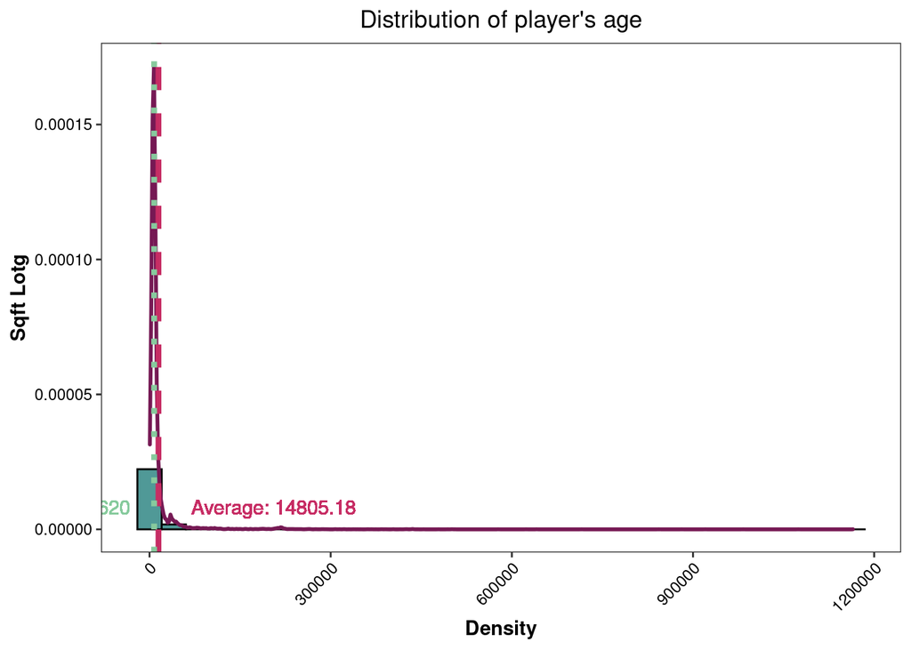

```r
avg <- round(mean(db_train$sqft_lot),2)
median <- round(median(db_train$sqft_lot),2)

# histogram and density
db_train %>%
  ggplot(aes(x = sqft_lot)) +
  geom_histogram(
    aes(y = ..density..),
    bins = 30,
    fill = "#509997",
    color = "black") +
  geom_density(color = "#761954", size = 1) +
  geom_vline(
    xintercept = avg,
    linetype = "dashed",
    color = "#c62d64",
    size = 1.5) +
  geom_text(aes(avg, 0, label = paste("Average:", avg), hjust = -0.2, vjust = -1), color = "#c62d64") +
  geom_vline(
    xintercept = median,
    linetype = "dotted",
    color = "#87ca9d",
    size = 1.5) +
  geom_text(aes(median, 0, label = paste("Median:", median), hjust = 1.2, vjust = -1), color = "#87ca9d") +
  ggtitle("Distribution of player's age") +
  CSGo::theme_csgo() +
  ylab("Sqft Lotg") +
  xlab("Density")
```

#### **sqft_above**

Below it is represented the histogram and the density of the variable. It is possible to see that the distribution of sqft_above is kind of symmetric but with some atypical values to the right.

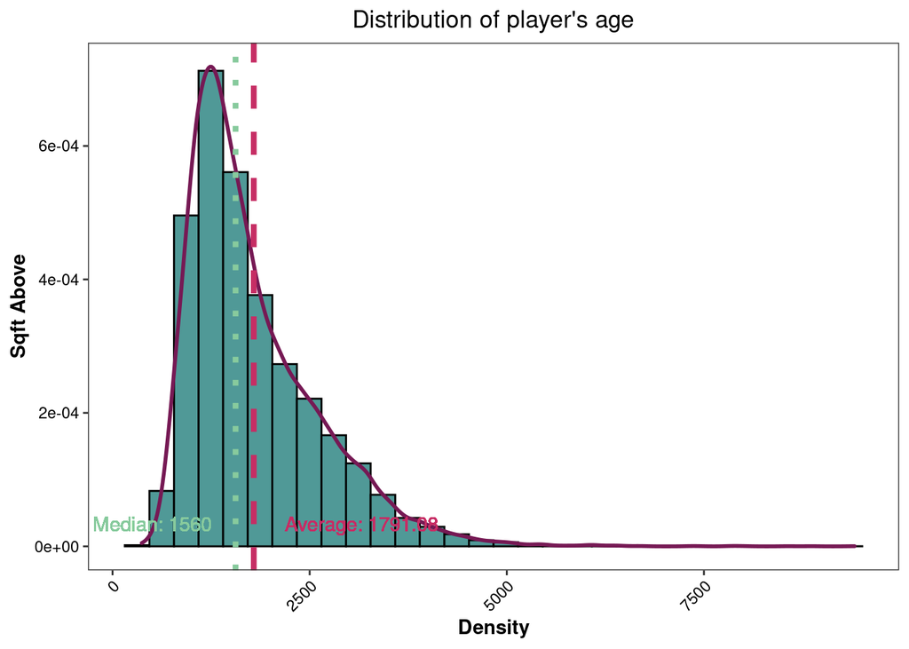

```r
avg <- round(mean(db_train$sqft_above),2)
median <- round(median(db_train$sqft_above),2)

# histogram and density
db_train %>%
  ggplot(aes(x = sqft_above)) +
  geom_histogram(
    aes(y = ..density..),
    bins = 30,
    fill = "#509997",
    color = "black") +
  geom_density(color = "#761954", size = 1) +
  geom_vline(
    xintercept = avg,
    linetype = "dashed",
    color = "#c62d64",
    size = 1.5) +
  geom_text(aes(avg, 0, label = paste("Average:", avg), hjust = -0.2, vjust = -1), color = "#c62d64") +
  geom_vline(
    xintercept = median,
    linetype = "dotted",
    color = "#87ca9d",
    size = 1.5) +
  geom_text(aes(median, 0, label = paste("Median:", median), hjust = 1.2, vjust = -1), color = "#87ca9d") +
  ggtitle("Distribution of player's age") +
  CSGo::theme_csgo() +
  ylab("Sqft Above") +
  xlab("Density")
```

#### **sqft_basement**

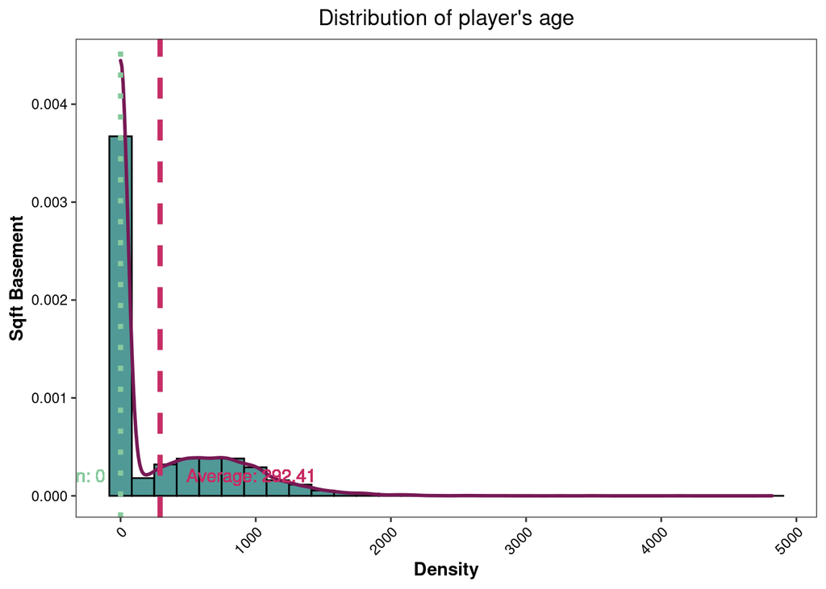

```r
avg <- round(mean(db_train$sqft_basement),2)
median <- round(median(db_train$sqft_basement),2)

# histogram and density
db_train %>%
  ggplot(aes(x = sqft_basement)) +
  geom_histogram(
    aes(y = ..density..),
    bins = 30,
    fill = "#509997",
    color = "black") +
  geom_density(color = "#761954", size = 1) +
  geom_vline(
    xintercept = avg,
    linetype = "dashed",
    color = "#c62d64",
    size = 1.5) +
  geom_text(aes(avg, 0, label = paste("Average:", avg), hjust = -0.2, vjust = -1), color = "#c62d64") +
  geom_vline(
    xintercept = median,
    linetype = "dotted",
    color = "#87ca9d",
    size = 1.5) +
  geom_text(aes(median, 0, label = paste("Median:", median), hjust = 1.2, vjust = -1), color = "#87ca9d") +
  ggtitle("Distribution of player's age") +
  CSGo::theme_csgo() +
  ylab("Sqft Basement") +
  xlab("Density")
```

### Categorical Variables

Below it is presented some descriptive analysis for the categorical variables against our target variable price.

#### **bedrooms**

First let’s take a look in the frequency table bellow.

```r
# freq table
table(db_train$bedrooms)
```

```
##
##    0    1    2    3    4    5    6    7    8    9   10   11   33
##   12  153 2183 7794 5473 1275  209   33    8    6    3    1    1
```

> Based on the table above we have decided to joing the more than 8 in the same category.

Below is presented the boxplot of price by bedrooms.

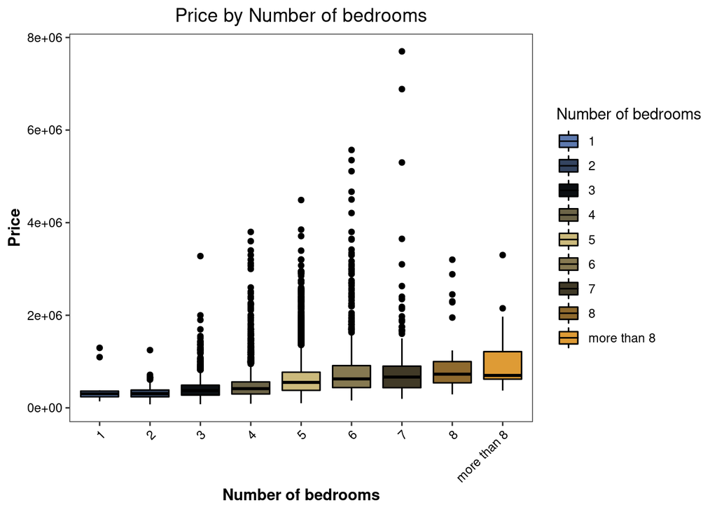

```r
db_train <- db_train %>%
  mutate(
    bedrooms_cat = ifelse(bedrooms >=8, "more than 8", as.factor(bedrooms))
  )

# bar plot
db_train %>%
  ggplot(aes(x = bedrooms_cat, y = price, fill = bedrooms_cat)) +
  geom_boxplot(color = "black") +
  ggtitle("Price by Number of bedrooms") +
  ylab("Price") +
  xlab("Number of bedrooms") +
  labs(fill = "Number of bedrooms") +
  CSGo::scale_fill_csgo()+
  CSGo::theme_csgo()
```

> The boxplot shows that the bigger the number of bedrooms bigger the price.

#### **bathrooms**

First let’s take a look in the frequency table bellow.

```r
# freq table
table(db_train$bathrooms)
```

```
##
##    0  0.5 0.75    1 1.25  1.5 1.75    2 2.25  2.5 2.75    3 3.25  3.5 3.75    4
##    9    3   57 3042    6 1140 2416 1546 1614 4282  943  587  470  587  129  111
## 4.25  4.5 4.75    5 5.25  5.5 5.75    6 6.25  6.5 6.75  7.5 7.75    8
##   62   76   21   16   11    7    2    6    2    1    1    1    1    2
```

> Based on the table above we have decided to joing the more than 4 in the same category and less than 1 in other category.

Below is presented the boxplot of price by bathrooms

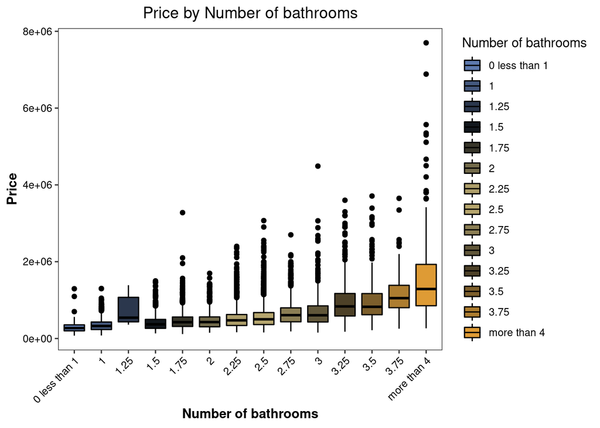

```r
db_train <- db_train %>%
  mutate(
    bathrooms = as.numeric(bathrooms),

    bathrooms_cat = as.factor(case_when(
      bathrooms >= 4 ~ "more than 4",
      bathrooms < 1 ~ "0 less than 1",
      TRUE ~ as.character(bathrooms))
  ))

# bar plot
db_train %>%
  ggplot(aes(x = bathrooms_cat, y = price, fill = bathrooms_cat)) +
  geom_boxplot(color = "black") +
  ggtitle("Price by Number of bathrooms") +
  ylab("Price") +
  xlab("Number of bathrooms") +
  labs(fill = "Number of bathrooms") +
  CSGo::scale_fill_csgo()+
  CSGo::theme_csgo()
```

> The boxplot shows that the bigger the number of bathrooms bigger the price.

#### **floors**

First let’s take a look in the frequency table bellow.

```r
# freq table
table(db_train$floors)
```

```
##
##    1  1.5    2  2.5    3  3.5
## 8448 1509 6569  130  490    5
```

> Based on the table above we have decided to joing the more than 2 in the same category.

Below is presented the boxplot of price by floors

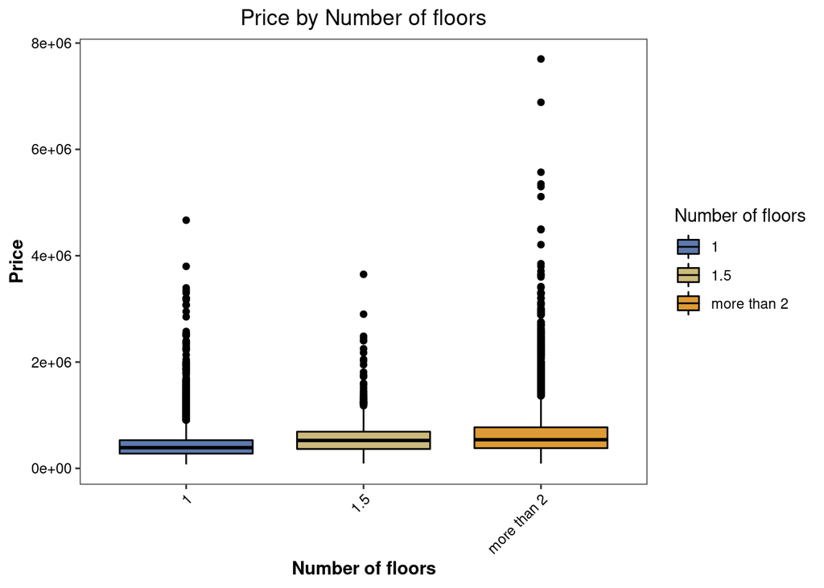

```r
db_train <- db_train %>%
  mutate(
   floors_cat = as.factor(case_when(
      floors >= 2 ~ "more than 2",
      TRUE ~ as.character(floors))
  ))

# bar plot
db_train %>%
  ggplot(aes(x = floors_cat, y = price, fill = floors_cat)) +
  geom_boxplot(color = "black") +
  ggtitle("Price by Number of floors") +
  ylab("Price") +
  xlab("Number of floors") +
  labs(fill = "Number of floors") +
  CSGo::scale_fill_csgo()+
  CSGo::theme_csgo()
```

> The boxplot shows that the number of floors does not influential in the price.

#### **waterfront**

First let’s take a look in the frequency table bellow.

```r
# freq table
table(db_train$waterfront)
```

```
##
## FALSE  TRUE
## 17018   133
```

> Based on the table above can see that we have very unbalanced classes for the waterfront variable. The most of the data is FALSE. However the boxplot bellow suggests that when the waterfront is TRUE the price of the houses are bigger.

Below is presented the boxplot of price by waterfront.

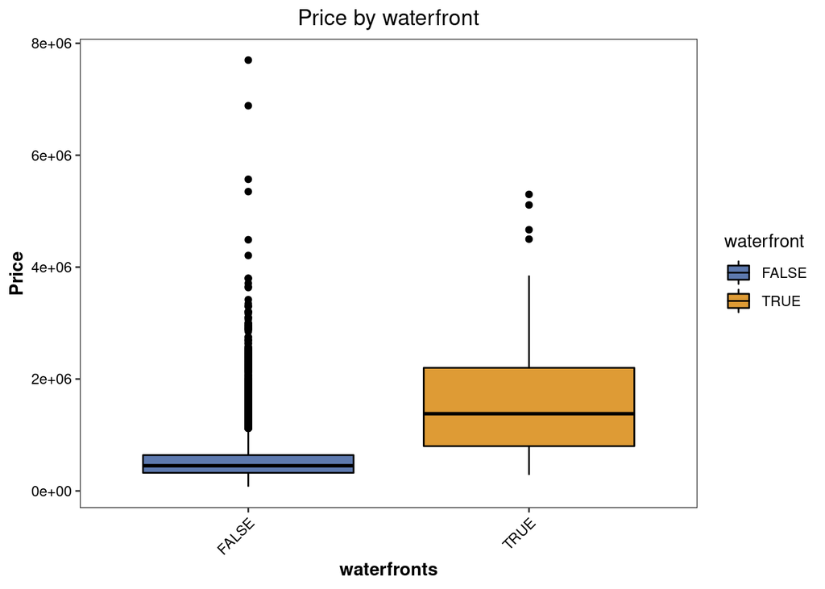

```r
# bar plot
db_train %>%
  ggplot(aes(x = waterfront, y = price, fill = waterfront)) +
  geom_boxplot(color = "black") +
  ggtitle("Price by waterfront") +
  ylab("Price") +
  xlab("waterfronts") +
  labs(fill = "waterfront") +
  CSGo::scale_fill_csgo()+
  CSGo::theme_csgo()
```

> The boxplot shows when the waterfront is TRUE the higher will be the prices.

#### **view**

First let’s take a look in the frequency table bellow.

```r
# freq table
table(db_train$view)
```

```
##
##     0     1     2     3     4
## 15450   272   770   407   252
```

Below is presented the boxplot of price by view.

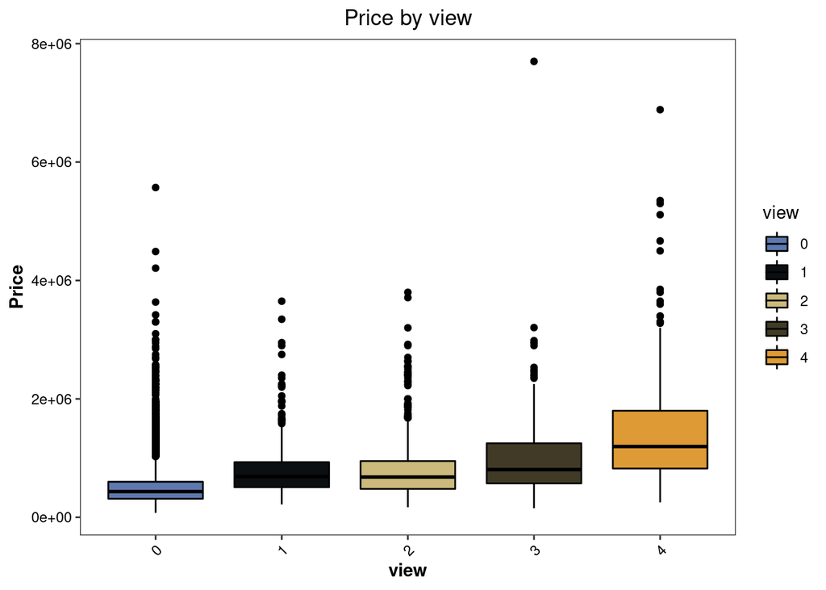

```r
db_train <- db_train %>%
  mutate(
   view = as.factor(view)
  )

# bar plot
db_train %>%
  ggplot(aes(x = view, y = price, fill = view)) +
  geom_boxplot(color = "black") +
  ggtitle("Price by view") +
  ylab("Price") +
  xlab("view") +
  labs(fill = "view") +
  CSGo::scale_fill_csgo()+
  CSGo::theme_csgo()
```

> The boxplot shows that bigger the view bigger the price.

#### **condition**

First let’s take a look in the frequency table bellow.

```r
# freq table
table(db_train$condition)
```

```
##
##     1     2     3     4     5
##    20   129 11120  4526  1356
```

> Based on the table above we decided to joing the categories 1 and 2 into the same category.

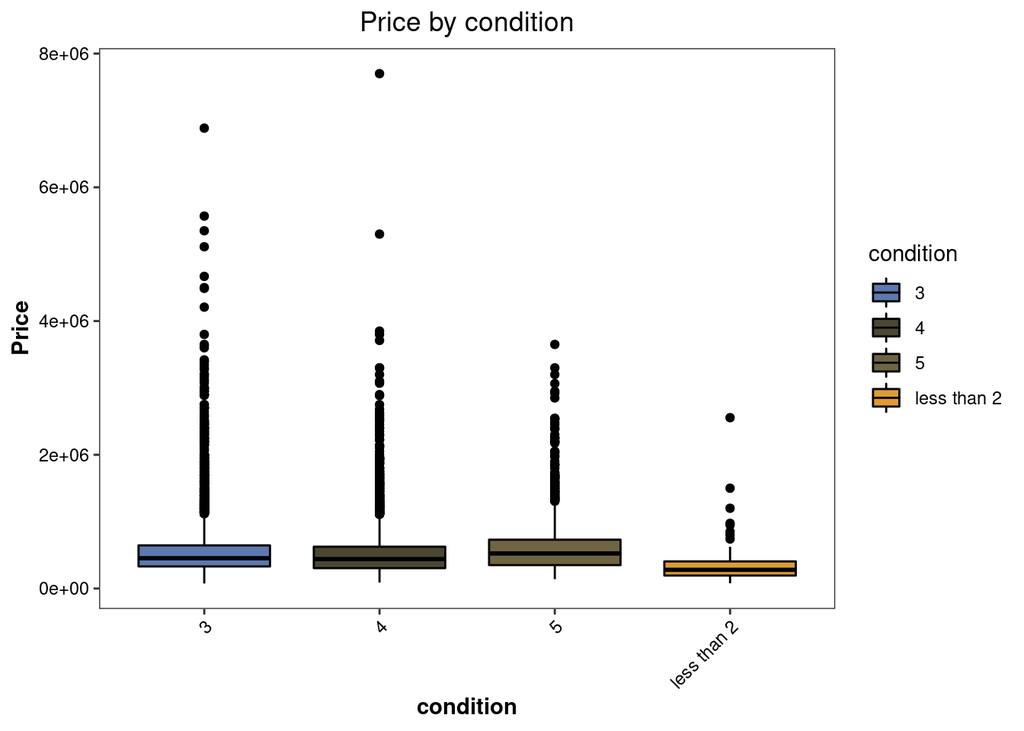

```r
db_train <- db_train %>%
  mutate(
   condition_cat = ifelse(as.numeric(condition) <= 2, "less than 2", as.factor(condition))
  )

# bar plot
db_train %>%
  ggplot(aes(x = condition_cat, y = price, fill = condition_cat)) +
  geom_boxplot(color = "black") +
  ggtitle("Price by condition") +
  ylab("Price") +
  xlab("condition") +
  labs(fill = "condition") +
  CSGo::scale_fill_csgo()+
  CSGo::theme_csgo()
```

> The boxplot shows that the condition has no influential in the price.

#### **grade**

First let’s take a look in the frequency table bellow.

```r
# freq table
table(db_train$grade)
```

```
##
##    3    4    5    6    7    8    9   10   11   12   13
##    3   20  183 1577 7147 4832 2075  921  310   71   12
```

> Based on the table above we decided to joing the categories 3, 4 and 5 into the same category and the 11, 12, 13 in other category.

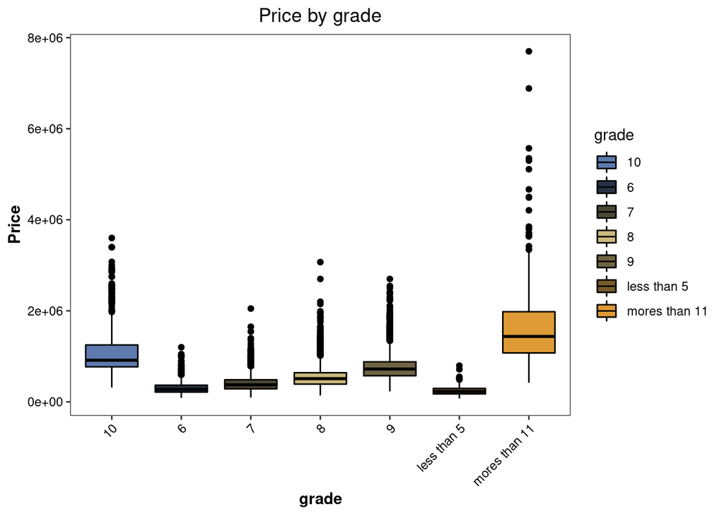

```r
db_train <- db_train %>%
  mutate(
    grade = as.numeric(grade),

    grade_cat = as.factor(case_when(
      grade <= 5 ~ "less than 5",
      grade >= 11 ~ "mores than 11",
      TRUE ~ as.character(grade))
  ))

# bar plot
db_train %>%
  ggplot(aes(x = as.factor(grade_cat), y = price, fill = as.factor(grade_cat))) +
  geom_boxplot(color = "black") +
  ggtitle("Price by grade") +
  ylab("Price") +
  xlab("grade") +
  labs(fill = "grade") +
  CSGo::scale_fill_csgo()+
  CSGo::theme_csgo()
```

> The boxplot shows that bigger the grades bigger the price.

### Correlation

Now we are going to perform a correlation study to see if the are any continuous explanatory variables are related to each other and also the most correlated variables with the price.

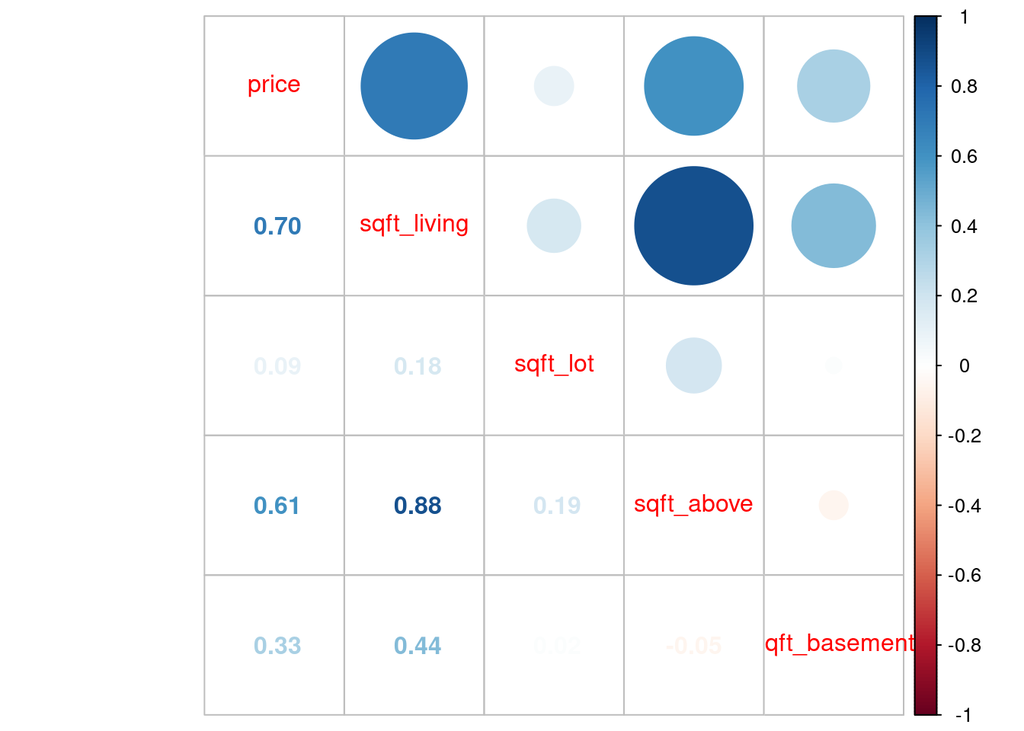

```r
require(corrplot)

db_train_contin <- db_train %>%
  select(
    price,
    sqft_living,
    sqft_lot,
    sqft_above,
    sqft_basement
  )

cor_result <- cor(db_train_contin, method = "pearson")

corrplot::corrplot.mixed(cor_result)
```

> It is possible to see that sqft_living and sqft_above presented a high correlation (0.88), so to avoid multicolinearty problems we will not consider the sqft_above in our model, this choice is also based on that the sqft_living has the higher correlation to our target variable (price) compared to sqft_above.

# Modelling

In this session we will train a linear regression to predict our target variable *price*. We will also run a step wise selection.

Let’s first define our start formula. We will not consider the following variables: sqft_above, condition, and floors.

```r
# formula
form <- formula(price ~ sqft_living + sqft_basement + sqft_lot + grade_cat + view + waterfront + bathrooms_cat + bedrooms_cat)
```

Now let’s train the model.

```r
# model
#lmStepAIC
set.seed(1992)
mod <- train(
  form,
  data = db_train,
  method = "lmStepAIC")
```

[output not shown]

[output cut: 7521 more lines]

[output not shown]

```r
summary(mod)
```

```
##
## Call:
## lm(formula = .outcome ~ sqft_living + sqft_basement + sqft_lot +
##     grade_cat6 + grade_cat7 + grade_cat8 + grade_cat9 + `grade_catless than 5` +
##     `grade_catmores than 11` + view1 + view2 + view3 + view4 +
##     waterfrontTRUE + bathrooms_cat1 + bathrooms_cat1.5 + bathrooms_cat1.75 +
##     bathrooms_cat2 + bathrooms_cat2.5 + bathrooms_cat2.75 + bathrooms_cat3.25 +
##     bathrooms_cat3.75 + `bathrooms_catmore than 4` + bedrooms_cat2 +
##     bedrooms_cat3 + bedrooms_cat4 + bedrooms_cat8 + `bedrooms_catmore than 8`,
##     data = dat)
##
## Residuals:
##      Min       1Q   Median       3Q      Max
## -1570917  -115050   -18995    91454  4535287
##
## Coefficients:
##                              Estimate Std. Error t value Pr(>|t|)
## (Intercept)                 4.253e+05  1.579e+04  26.930  < 2e-16 ***
## sqft_living                 1.618e+02  4.090e+00  39.558  < 2e-16 ***
## sqft_basement               4.350e+01  4.731e+00   9.194  < 2e-16 ***
## sqft_lot                   -3.642e-01  4.546e-02  -8.011 1.21e-15 ***
## grade_cat6                 -4.141e+05  1.202e+04 -34.455  < 2e-16 ***
## grade_cat7                 -3.504e+05  9.969e+03 -35.149  < 2e-16 ***
## grade_cat8                 -2.678e+05  9.253e+03 -28.942  < 2e-16 ***
## grade_cat9                 -1.448e+05  9.122e+03 -15.879  < 2e-16 ***
## `grade_catless than 5`     -4.389e+05  1.924e+04 -22.808  < 2e-16 ***
## `grade_catmores than 11`    3.156e+05  1.417e+04  22.266  < 2e-16 ***
## view1                       1.350e+05  1.369e+04   9.857  < 2e-16 ***
## view2                       7.958e+04  8.376e+03   9.500  < 2e-16 ***
## view3                       1.303e+05  1.152e+04  11.307  < 2e-16 ***
## view4                       3.191e+05  1.819e+04  17.539  < 2e-16 ***
## waterfrontTRUE              4.639e+05  2.444e+04  18.981  < 2e-16 ***
## bathrooms_cat1              5.906e+04  7.322e+03   8.066 7.72e-16 ***
## bathrooms_cat1.5            3.068e+04  8.273e+03   3.709 0.000209 ***
## bathrooms_cat1.75           2.143e+04  6.514e+03   3.290 0.001004 **
## bathrooms_cat2              2.874e+04  7.322e+03   3.925 8.69e-05 ***
## bathrooms_cat2.5           -4.953e+04  5.467e+03  -9.060  < 2e-16 ***
## bathrooms_cat2.75          -2.269e+04  8.389e+03  -2.704 0.006849 **
## bathrooms_cat3.25           5.470e+04  1.125e+04   4.862 1.17e-06 ***
## bathrooms_cat3.75           9.913e+04  2.031e+04   4.880 1.07e-06 ***
## `bathrooms_catmore than 4`  2.025e+05  1.477e+04  13.710  < 2e-16 ***
## bedrooms_cat2               6.884e+04  1.919e+04   3.587 0.000335 ***
## bedrooms_cat3               6.997e+04  6.770e+03  10.335  < 2e-16 ***
## bedrooms_cat4               2.252e+04  4.240e+03   5.311 1.10e-07 ***
## bedrooms_cat8              -6.858e+04  3.921e+04  -1.749 0.080349 .
## `bedrooms_catmore than 8`   1.007e+05  5.133e+04   1.962 0.049817 *
## ---
## Signif. codes:  0 '***' 0.001 '**' 0.01 '*' 0.05 '.' 0.1 ' ' 1
##
## Residual standard error: 221700 on 17122 degrees of freedom
## Multiple R-squared:  0.6373, Adjusted R-squared:  0.6367
## F-statistic:  1075 on 28 and 17122 DF,  p-value: < 2.2e-16
```

So, the final model will be:

```r
mod$finalModel
```

```
##
## Call:
## lm(formula = .outcome ~ sqft_living + sqft_basement + sqft_lot +
##     grade_cat6 + grade_cat7 + grade_cat8 + grade_cat9 + `grade_catless than 5` +
##     `grade_catmores than 11` + view1 + view2 + view3 + view4 +
##     waterfrontTRUE + bathrooms_cat1 + bathrooms_cat1.5 + bathrooms_cat1.75 +
##     bathrooms_cat2 + bathrooms_cat2.5 + bathrooms_cat2.75 + bathrooms_cat3.25 +
##     bathrooms_cat3.75 + `bathrooms_catmore than 4` + bedrooms_cat2 +
##     bedrooms_cat3 + bedrooms_cat4 + bedrooms_cat8 + `bedrooms_catmore than 8`,
##     data = dat)
##
## Coefficients:
##                (Intercept)                 sqft_living
##                  4.253e+05                   1.618e+02
##              sqft_basement                    sqft_lot
##                  4.350e+01                  -3.642e-01
##                 grade_cat6                  grade_cat7
##                 -4.141e+05                  -3.504e+05
##                 grade_cat8                  grade_cat9
##                 -2.678e+05                  -1.448e+05
##     `grade_catless than 5`    `grade_catmores than 11`
##                 -4.389e+05                   3.156e+05
##                      view1                       view2
##                  1.350e+05                   7.958e+04
##                      view3                       view4
##                  1.303e+05                   3.191e+05
##             waterfrontTRUE              bathrooms_cat1
##                  4.639e+05                   5.906e+04
##           bathrooms_cat1.5           bathrooms_cat1.75
##                  3.068e+04                   2.143e+04
##             bathrooms_cat2            bathrooms_cat2.5
##                  2.874e+04                  -4.953e+04
##          bathrooms_cat2.75           bathrooms_cat3.25
##                 -2.269e+04                   5.470e+04
##          bathrooms_cat3.75  `bathrooms_catmore than 4`
##                  9.913e+04                   2.025e+05
##              bedrooms_cat2               bedrooms_cat3
##                  6.884e+04                   6.997e+04
##              bedrooms_cat4               bedrooms_cat8
##                  2.252e+04                  -6.858e+04
##  `bedrooms_catmore than 8`
##                  1.007e+05
```

And below is presented the results of this model:

```r
mod$results
```

```
##   parameter     RMSE  Rsquared      MAE   RMSESD RsquaredSD    MAESD
## 1      none 223205.1 0.6310368 146329.2 4937.735 0.01012315 1407.002
```

# Model Evaluation

In this session we are going to apply the model above in our test data set to see how it performs in a new data set.

First let’s transform some categories we created before in our test data set, and then apply our model to it.

```r
db_test <- db_test %>%
  mutate(
    bedrooms_cat = ifelse(bedrooms >=8, "more than 8", as.factor(bedrooms)),

    bathrooms = as.numeric(bathrooms),

    view = as.factor(view),

    bathrooms_cat = as.factor(case_when(
      bathrooms >= 4 ~ "more than 4",
      bathrooms < 1 ~ "0 less than 1",
      TRUE ~ as.character(bathrooms))
    ),

    grade = as.numeric(grade),

    grade_cat = as.factor(case_when(
      grade <= 5 ~ "less than 5",
      grade >= 11 ~ "mores than 11",
      TRUE ~ as.character(grade))
    )
  )

db_test <- db_test %>%
  mutate(
    pred = predict(mod, db_test)
  )
```

Now let’s plot the predicted vs observed.

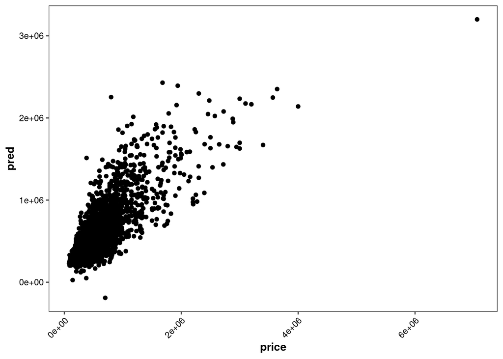

```r
db_test %>% ggplot(aes(x = price, y = pred)) +
  geom_point() +
  CSGo::theme_csgo()
```

# Conclusion

The model developed to predict the price was considered satisfactory. However the use and understanding of new variables or transformation would improve our results.